# Correlations

Author

Jérôme Pasquier

Published

July 24, 2025

## Raw correlations

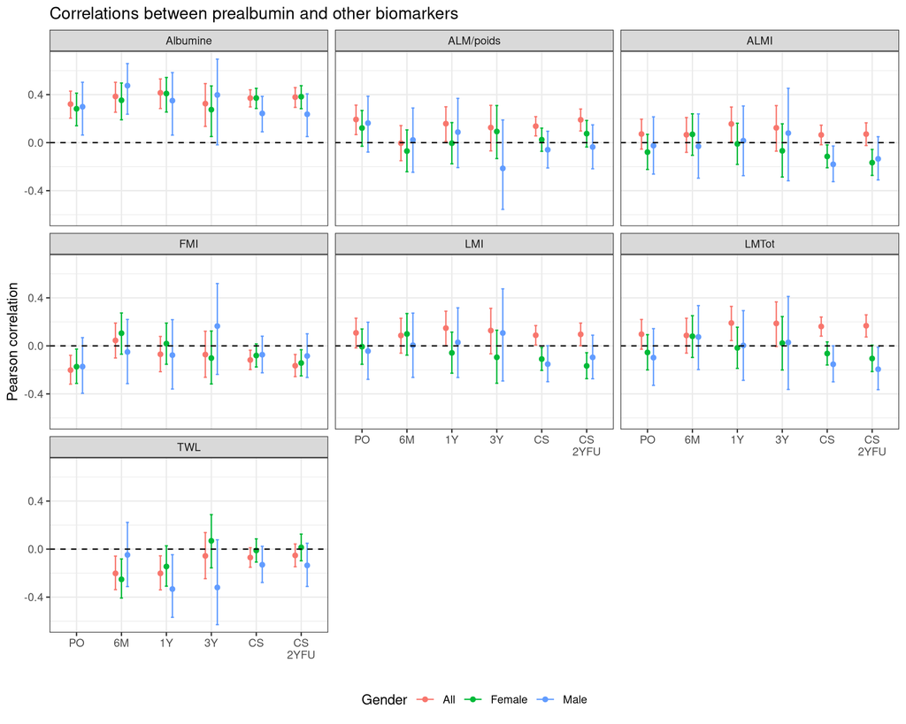

Figure 1: Correlations between prealbumin and other biomarkers (analyses from 2025-05-28 and 2025-07-03)

Download SVG

Table 1: Sample sizes for the correlations between prealbumin and other biomarkers

| gender | PO | 6M | 1Y | 3Y | CS | CS_2YFU |
| --- | --- | --- | --- | --- | --- | --- |
| All | 237-246 | 180-182 | 175-177 | 98-104 | 564-577 | 416-427 |
| Female | 169-178 | 126-128 | 130-131 | 75-78 | 407-413 | 307-312 |
| Male | 67-68 | 54 | 45-46 | 23-26 | 157-164 | 109-115 |

Download CSV

### Correlations estimated from a mixed-effects model of the longitudinal data

The model of the prealbumin ($Y$) with all possible interactions beteween the biomarker ($X$), the gender ($M$) and the period ($T_1$, $T_2$ and $T_3$) is given by

$$\begin{aligned}
Y =\;
& \beta_0
+ \beta_X\, X
+ \beta_M\, M
+ \beta_{T_1}\, T_1
+ \beta_{T_2}\, T_2
+ \beta_{T_3}\, T_3 \\
& + \beta_{X:M}\, X\, M
+ \beta_{X:T_1}\, X\, T_1
+ \beta_{X:T_2}\, X\, T_2
+ \beta_{X:T_3}\, X\, T_3 \\
& + \beta_{M:T_1}\, M\, T_1
+ \beta_{M:T_2}\, M\, T_2
+ \beta_{M:T_3}\, M\, T_3 \\
& + \beta_{X:M:T_1}\, X\, M\, T_1
+ \beta_{X:M:T_2}\, X\, M\, T_2
+ \beta_{X:M:T_3}\, X\, M\, T_3 \\
& + b_\text{IPP} + \varepsilon,
\end{aligned}$$

where $b_\text{IPP} \sim N(0, \tau^2)$ is the random intercept for the individual patient and $\varepsilon \sim N(0, \sigma^2)$ is the error term.

Gathering the terms that are not multiplied by the biomarker $X$ gives

$$\alpha = \beta_0 + \beta_M\, M + \beta_{T_1}\, T_1 + \beta_{T_2}\, T_2
+ \beta_{T_3}\, T_3 + \beta_{M:T_1}\, M\, T_1
+ \beta_{M:T_2}\, M\, T_2 + \beta_{M:T_3}\, M\, T_3.$$

whereas the terms that are multiplied by the biomarker $X$ are gathered in

$$\begin{aligned}
\gamma =\;
& \beta_X + \beta_{X:M}\, M + \beta_{X:T_1}\, T_1 + \beta_{X:T_2}\, T_2
+ \beta_{X:T_3}\, T_3 \\
& + \beta_{X:M:T_1}\, M\, T_1 + \beta_{X:M:T_2}\, M\, T_2
+ \beta_{X:M:T_3}\, M\, T_3.
\end{aligned}$$

The model can then be rewritten as

$$Y = \alpha + \gamma\, X + b_\text{IPP} + \varepsilon.$$

Denoting the set of covariables $M$, $T_1$, $T_2$ and $T_3$ by $Z$, the partial correlations between the prealbumin and the biomarkers can then be calculated as

$$\rho(Z) = \mathop{\mathrm{Cor}}(X, Y \mid Z)
= \frac{\mathop{\mathrm{Cov}}(X, Y \mid Z)}{\sqrt{\mathop{\mathrm{Var}}(X \mid Z) \mathop{\mathrm{Var}}(Y \mid Z)}}.$$

The variance of the biomarker $Y$ given the covariables $Z$ is given by

$$\mathop{\mathrm{Var}}(Y \mid Z) = \mathop{\mathrm{Var}}(\alpha + \gamma\, X + b_\text{IPP} + \varepsilon \mid Z)
= \gamma^2 \mathop{\mathrm{Var}}(X \mid Z) + \tau^2 + \sigma^2,$$

$$\mathop{\mathrm{Cov}}(X, Y \mid Z) = \mathop{\mathrm{Cov}}(X, \alpha + \gamma\, X + b_\text{IPP}
+ \varepsilon \mid Z)
= \gamma \mathop{\mathrm{Cov}}(X, X \mid Z) = \gamma \mathop{\mathrm{Var}}(X \mid Z).$$

The partial correlation between the prealbumin and the biomarker can then be rewritten as

$$\rho(Z) = \frac{\gamma\, v_X(Z)}{\sqrt{\gamma^2 v_X(Z)^2 + \tau^2 + \sigma^2}},
\quad\text{with}\quad v_X(Z) = \mathop{\mathrm{Var}}(X \mid Z).$$

The estimator of the partial correlation can be calculated as

$$\hat\rho(Z) = \frac{\hat\gamma\, \hat v_X(Z)}{\sqrt{\hat\gamma^2 \hat v_X(Z)^2
+ \hat\tau^2 + \hat\sigma^2}}.$$

The estimates $\hat\gamma$, $\hat\tau$ and $\hat\sigma$ are obtained directly from from the linear mixed effect model.

The estimator $\hat v_X(Z)$ is calculated as the sample variance of $X$ within the stratum defined by $Z$. There is at most one observations per patient (IPP) in each stratum.

Finally, the standard error of the partial correlation estimator is obtained using the delta method.

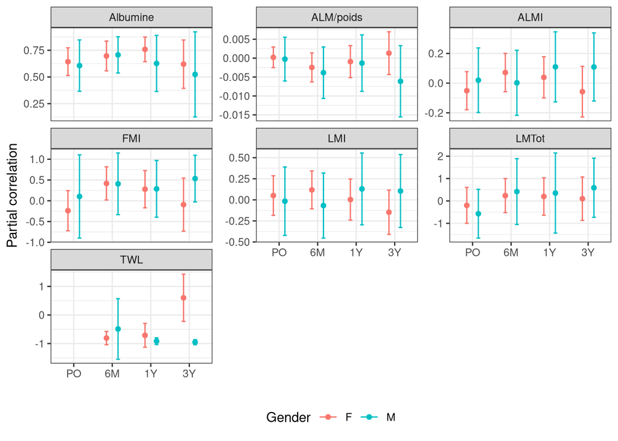

Figure 2: Partial correlations between prealbumin and other biomarkers estimated from the longitudinal data using a linear mixed model including all possible interactions between gender, period, and the biomarker.

Download SVG